# Praca domowa 2

Adrian Bednarz

October 24, 2018

## Przed

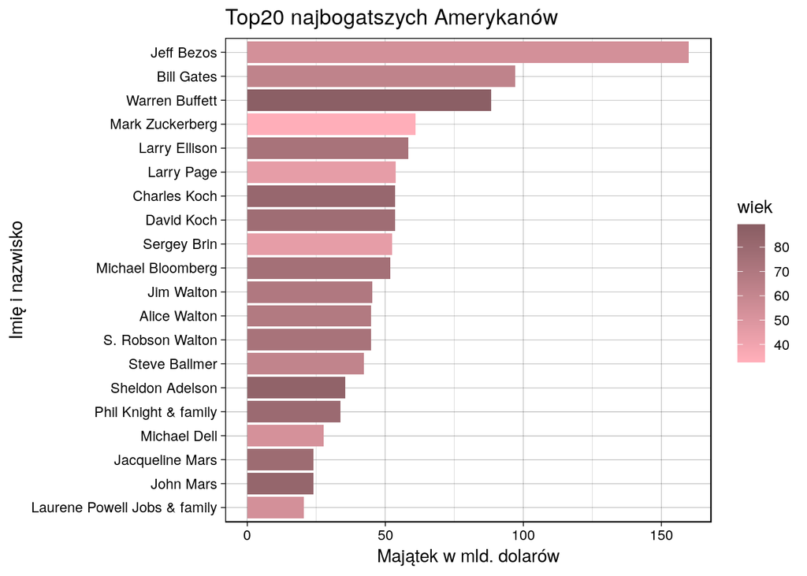

Patrząc na ten wykres z punktu czysto technicznego - jest on wykonany poprawnie. Nie znajdziemy na nim redundantnych informacji - poprawnie ukazuje informacje na temat wieku i majątku najbogatszych Amerykanów. Nie ma problemów ze zrozumieniem informacji, które są w nim zawarte. Z łatwością można zidentyfikować, że Warren Buffet jest starszy niż Mark Zuckerberg - czy też, że pan Zuckerberg jest najmłodszy w zestawieniu. Ale trzeba chcieć to zauważyć.

Pytanie, które nasuwa się przy analizie tego wykresu brzmi: co ten wykres chce tak na prawdę przekazać? Mimo prostoty wykresu mam problem z udzieleniem odpowiedzi na to pytanie. Jeśli autor chciał pokazać, że pan Zuckerberg jest wyróżniająco młody to zaznaczenie wieku kolorem było nie najlepszym pomysłem - tak trudno porównać podobne wielkości. Jeśli celem było po prostu pokazanie kto ma ile pieniędzy - to po co nam informacja o wieku?

A co jeśli chcielibyśmy pokazać, że niektóre osoby są wyróżniająco młode a inne **bardzo** bogate?

## Po

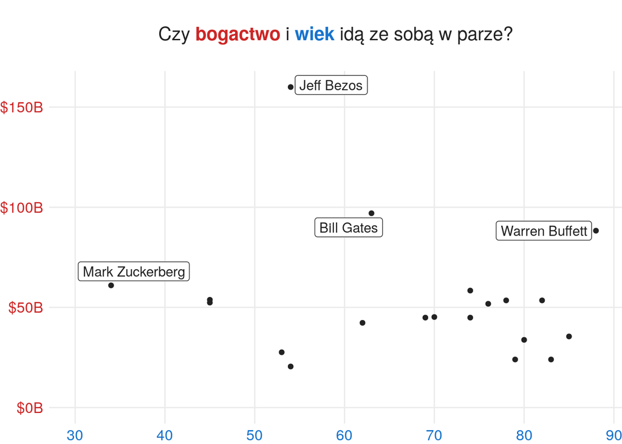

Teraz już jasno widzimy wyróżniające się osoby - zarówno te o wysokim majątku, jak i te, które dodatkowo są jeszcze młode. Pytanie w tytule wykresu przyciąga uwagę czytelnika i pobudza do refleksji - sugeruje też kierunek analizy wykresu i uwypukla historię, która za nim stoi. Sama reprezentacja informacji pokazuje, że pan Bezos jest jedną z młodszych osób w czołówce czego nie było od razu widać w poprzedniej reprezentacji. Cztery osobistości o wyróżniającej charakterystyce zostały uwypuklone przy pomocy opisu tekstowego.